# EDA_amy

Amy Pitts

2022-04-19

## Load Data

```r
df = read_excel("Proj 4 data.xlsx") %>%
  janitor::clean_names() %>%
  mutate(
    group = factor(group),
    time_int = case_when(
      time == 1 ~ "baseline",
      time == 2 ~ "6-month",
      time == 3 ~ "12-month"
    ),
    time_int = factor(time_int, levels = c("baseline", "6-month","12-month")),
    school = factor(school)
  ) %>%
  separate(id, c("id", "one"), sep="_") %>%
  select(-one) %>%
  mutate(id = as.numeric(id))
df %>% head()
```

```
## # A tibble: 6 × 6
##      id  time group   sfd school time_int
##   <dbl> <dbl> <fct> <dbl> <fct>  <fct>
## 1  1001     1 1        14 1      baseline
## 2  1001     3 1         7 1      12-month
## 3  1001     2 1        14 1      6-month
## 4  1002     1 1         0 1      baseline
## 5  1002     3 1         0 1      12-month
## 6  1002     2 1         0 1      6-month
```

Data Summary

```r
df %>% select(-c(id, time)) %>%
  tbl_summary(by=group) %>%
  add_overall()
```

| **Characteristic** | **Overall**, N = 324<sup>1</sup> | **0**, N = 147<sup>1</sup> | **1**, N = 177<sup>1</sup> |
| --- | --- | --- | --- |
| sfd | 12.0 (9.0, 14.0) | 12.0 (9.0, 14.0) | 12.0 (9.5, 14.0) |
| Unknown | 28 | 10 | 18 |
| school |  |  |  |
| 1 | 84 (26%) | 0 (0%) | 84 (47%) |
| 2 | 63 (19%) | 63 (43%) | 0 (0%) |
| 3 | 93 (29%) | 0 (0%) | 93 (53%) |
| 4 | 84 (26%) | 84 (57%) | 0 (0%) |
| time_int |  |  |  |
| baseline | 108 (33%) | 49 (33%) | 59 (33%) |
| 6-month | 108 (33%) | 49 (33%) | 59 (33%) |
| 12-month | 108 (33%) | 49 (33%) | 59 (33%) |

<sup>1</sup> Median (IQR); n (%)

```r
df %>% select(-c(id, time)) %>%
  filter(time_int == "baseline") %>%
  tbl_summary(by=group) %>%
  add_overall()
```

| **Characteristic** | **Overall**, N = 108<sup>1</sup> | **0**, N = 49<sup>1</sup> | **1**, N = 59<sup>1</sup> |
| --- | --- | --- | --- |
| sfd | 11.0 (7.0, 13.0) | 11.0 (7.8, 13.2) | 11.0 (7.0, 12.0) |
| Unknown | 3 | 1 | 2 |
| school |  |  |  |
| 1 | 28 (26%) | 0 (0%) | 28 (47%) |
| 2 | 21 (19%) | 21 (43%) | 0 (0%) |
| 3 | 31 (29%) | 0 (0%) | 31 (53%) |
| 4 | 28 (26%) | 28 (57%) | 0 (0%) |
| time_int |  |  |  |
| baseline | 108 (100%) | 49 (100%) | 59 (100%) |
| 6-month | 0 (0%) | 0 (0%) | 0 (0%) |
| 12-month | 0 (0%) | 0 (0%) | 0 (0%) |

<sup>1</sup> Median (IQR); n (%)

```r
# at baseline
df %>% select(-id) %>%
  filter(time == 1) %>%
  select(group, sfd) %>%
  tbl_summary(by=group) %>%
  add_overall() %>%
  add_p()
```

| **Characteristic** | **Overall**, N = 108<sup>1</sup> | **0**, N = 49<sup>1</sup> | **1**, N = 59<sup>1</sup> | **p-value**<sup>2</sup> |
| --- | --- | --- | --- | --- |
| sfd | 11.0 (7.0, 13.0) | 11.0 (7.8, 13.2) | 11.0 (7.0, 12.0) | 0.4 |
| Unknown | 3 | 1 | 2 |  |

<sup>1</sup> Median (IQR)  
<sup>2</sup> Wilcoxon rank sum test

Spaghetti plot

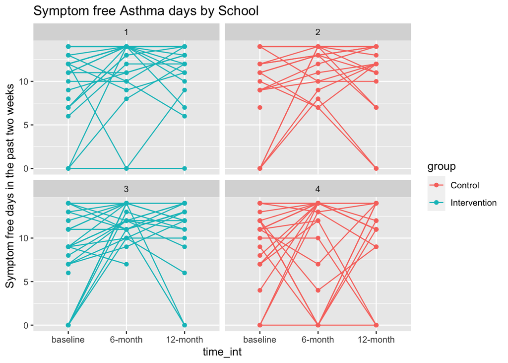

```r
df %>%
  mutate(
    group = ifelse(group == 0 , "Control", "Intervention")
  ) %>%
  ggplot(aes(y=sfd, x=time_int, group=id, color = group))+
  geom_point() +
  geom_line() +
  facet_wrap(~school) +
  labs(
    title = "Symptom free Asthma days by School ",
    y = "Symptom free days in the past two weeks"
  )
```

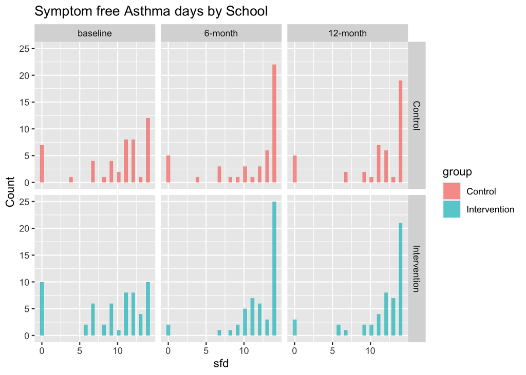

```r
df %>%
  mutate(
    group = ifelse(group == 0 , "Control", "Intervention")
  ) %>%
  ggplot(aes(x=sfd, fill = group))+
  geom_histogram(position = "identity", alpha = 0.7) +
  facet_grid(group~time_int) +
  labs(
    title = "Symptom free Asthma days by School ",
    y = "Count"
  )
```

Want to use sfd_reverse so we are looking at days where there are symptoms.

Why is there is someone that had zero days?

```r
df %>%
  filter(sfd == 0) %>%
  select(id) %>%
  group_by(id) %>%
  count() %>%
  arrange(desc(n))
```

```
## # A tibble: 25 × 2
## # Groups:   id [25]
##       id     n
##    <dbl> <int>
##  1  1002     3
##  2  2009     2
##  3  3011     2
##  4  3022     2
##  5  4014     2
##  6  4024     2
##  7  1010     1
##  8  1020     1
##  9  1023     1
## 10  2001     1
## # … with 15 more rows
```

There are 5 people with only 2 zero days.

```r
df %>%
  filter(id %in% c("2009", "3011", "3022", "4014", "4024")) %>%
  filter(sfd != 0)
```

```
## # A tibble: 5 × 6
##      id  time group   sfd school time_int
##   <dbl> <dbl> <fct> <dbl> <fct>  <fct>
## 1  2009     2 0         8 2      6-month
## 2  3011     2 1        11 3      6-month
## 3  3022     2 1        14 3      6-month
## 4  4014     1 0        12 4      baseline
## 5  4024     3 0        12 4      12-month
```

Not all on the middle obs but some are….

Missing data

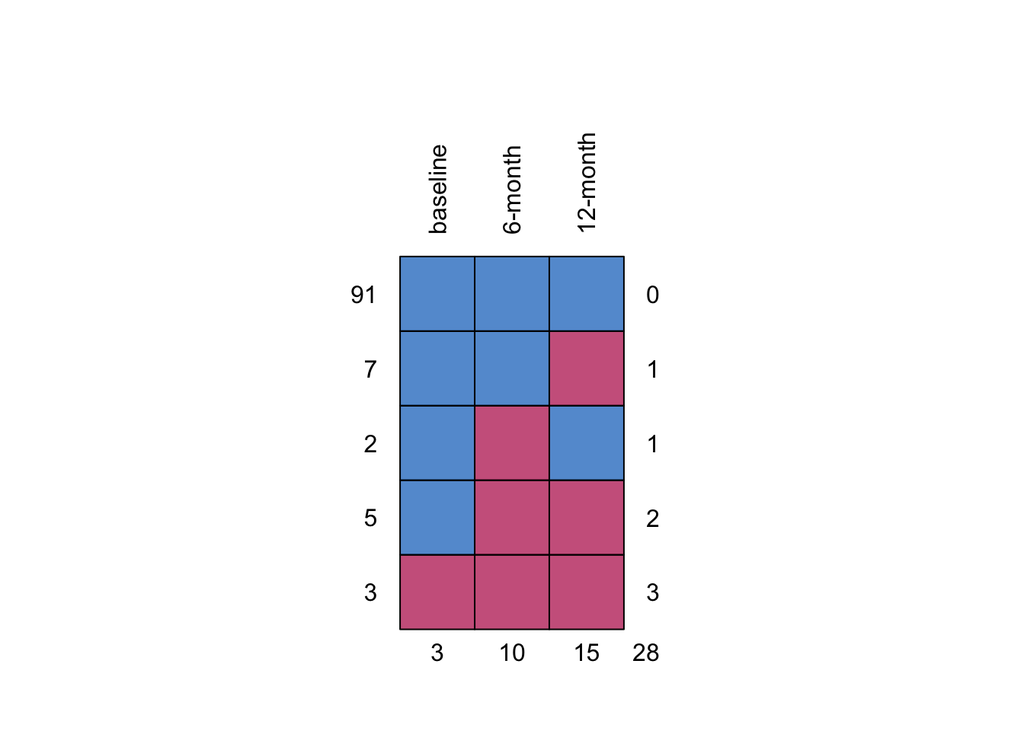

```
##    baseline 6-month 12-month
## 91        1       1        1  0
## 7         1       1        0  1
## 2         1       0        1  1
## 5         1       0        0  2
## 3         0       0        0  3
##           3      10       15 28
```

```r
data_spread_day = df %>%
  pivot_wider(
    names_from = time_int,
    id_cols = id,
    #names_prefix = "day",
    values_from = sfd
)

data_spread_day %>%
 select(-c(id)) %>%
  md.pattern(rotate.names = TRUE)
```

So the 3 people that have missing obs for all `sfd` are just going to be excluded.

As long as the people have baseline obs then we can used them. So 14 people with have observations extrapolated.

### Binomial Model

The Model in question:

$Y_i \sim Bin(14, p_i)$.

Let $i$ be subject, $j \in (1,2,3,4)$ be school, and $k \in (1,2,3)$ by the measurement

$$\log \left(\frac{p_{ijk}}{1-p_{ijk}} \right) = \beta_0 + \beta_1
School_{ij} + \beta_2 Treat_{i}
+ \beta_3 time_{ijk} + \beta_4 Treat_i \times time_{ijk} + \alpha_{0i} +
\alpha_{0j} + \epsilon_{ijk}$$

Where $\alpha_{0i}$ and $\alpha_{0j}$ are random intercept for subject and school.

- one model with continuous time
- one model with categorical time

[This is a interesting resrouce on negative binomial](https://www.nature.com/articles/s41598-020-73883-7)

## Time as Continous

```r
m.p <- glmer(sfd ~  group + time + time * group + (1|id) + (1|school),
              data = df,
              family = poisson)
```

```
## boundary (singular) fit: see help('isSingular')
```

```r
#summary(m.p)


m.b <- glmer(cbind(sfd, 14-sfd) ~  group + time + time * group + (1|id) + (1|school),
              data = df,
              family = binomial)
#summary(m.b)


m.nb <- glmer.nb(sfd ~ group + time + time * group + (1|id) + (1|school),
              data = df,
              verbose=FALSE)
```

```
## boundary (singular) fit: see help('isSingular')
```

```r
#summary(m.nb)

## The neg.binomial theta parameter:
#getME(m.nb, "glmer.nb.theta")

var_names = c("intercept", "group1", "time", "group1:time")
mod.nb <- summary(m.nb)
mod.b <- summary(m.b)
mod.p <- summary(m.p)

est_nb_df = mod.nb$coefficients %>% as_tibble() %>%
  janitor::clean_names() %>%
  mutate(var_names = var_names) %>%
  relocate(var_names) %>%
  rename(est_nb = estimate,
         p_nb = pr_z) %>%
  select(var_names, est_nb, p_nb)
est_b_df = mod.b$coefficients %>% as_tibble() %>%
  janitor::clean_names() %>%
  mutate(var_names = var_names) %>%
  relocate(var_names) %>%
  rename(est_b = estimate,
         p_b = pr_z) %>%
  select(var_names, est_b, p_b)
est_p_df = mod.p$coefficients %>% as_tibble() %>%
   janitor::clean_names() %>%
  mutate(var_names = var_names) %>%
  relocate(var_names) %>%
  rename(est_p = estimate,
         p_p = pr_z) %>%
  select(var_names, est_p, p_p)

full_join(est_b_df, est_p_df, by="var_names") %>%
  full_join(est_nb_df, by = "var_names") %>%
  mutate_at(2:7, round, 3)
```

```
## # A tibble: 4 × 7
##   var_names    est_b   p_b  est_p   p_p est_nb  p_nb
##   <chr>        <dbl> <dbl>  <dbl> <dbl>  <dbl> <dbl>
## 1 intercept    0.943 0.001  2.19  0      2.19  0
## 2 group1      -0.786 0.033 -0.102 0.343 -0.103 0.346
## 3 time         0.334 0      0.063 0.053  0.063 0.058
## 4 group1:time  0.45  0      0.066 0.133  0.067 0.139
```

# Time as Categorical

```r
df1 = df %>% mutate(time = factor(time))
m.p <- glmer(sfd ~  group + time + time * group + (1|id) + (1|school),
              data = df1,
              family = poisson)
```

```
## boundary (singular) fit: see help('isSingular')
```

```r
#summary(m.p)

m.b <- glmer(cbind(sfd, 14-sfd) ~  group + time + time * group + (1|id) + (1|school),
              data = df1,
              family = binomial)
#summary(m.b)


m.nb <- glmer.nb(sfd ~ group + time + time * group + (1|id) + (1|school),
              data = df1,
              verbose=FALSE)
```

```
## boundary (singular) fit: see help('isSingular')
```

```r
#summary(m.nb)

## The neg.binomial theta parameter:
#getME(m.nb, "glmer.nb.theta")

var_names = c("intercept", "group1", "time2", "time3", "group1:time2","group1:time3")
mod.nb <- summary(m.nb)
mod.b <- summary(m.b)
mod.p <- summary(m.p)

est_nb_df = mod.nb$coefficients %>% as_tibble() %>%
  janitor::clean_names() %>%
  mutate(var_names = var_names) %>%
  relocate(var_names) %>%
  rename(est_nb = estimate,
         p_nb = pr_z) %>%
  select(var_names, est_nb, p_nb)
est_b_df = mod.b$coefficients %>% as_tibble() %>%
  janitor::clean_names() %>%
  mutate(var_names = var_names) %>%
  relocate(var_names) %>%
  rename(est_b = estimate,
         p_b = pr_z) %>%
  select(var_names, est_b, p_b)
est_p_df = mod.p$coefficients %>% as_tibble() %>%
   janitor::clean_names() %>%
  mutate(var_names = var_names) %>%
  relocate(var_names) %>%
  rename(est_p = estimate,
         p_p = pr_z) %>%
  select(var_names, est_p, p_p)

full_join(est_b_df, est_p_df, by="var_names") %>%
  full_join(est_nb_df, by = "var_names")  %>%
  mutate_at(2:7, round, 3)
```

```
## # A tibble: 6 × 7
##   var_names     est_b   p_b  est_p   p_p est_nb  p_nb
##   <chr>         <dbl> <dbl>  <dbl> <dbl>  <dbl> <dbl>
## 1 intercept     1.18  0      2.23  0      2.23  0
## 2 group1       -0.42  0.206 -0.069 0.394 -0.069 0.395
## 3 time2         0.689 0      0.136 0.035  0.136 0.037
## 4 time3         0.628 0      0.126 0.056  0.126 0.059
## 5 group1:time2  0.936 0      0.157 0.075  0.158 0.077
## 6 group1:time3  0.773 0      0.14  0.119  0.14  0.123
```

## Transform to Continous outcome

Section 4.7 (Comparing Ordinal Endpoints by Wilcoxon-Mann-whitney Test) of my book says that if there are 5 or more categories, one can assign a score to each category and treat the change from the baseline of the score as a continous variable. Then we can apply the Equation 4.4.

Since the ordinal outcome of interest is symptom free days a larger value is better becuase it implies that more of the days were spent without any symptoms. Since larger is better the score I will be assigning to each of the categories is an idenitiy map to the day value.

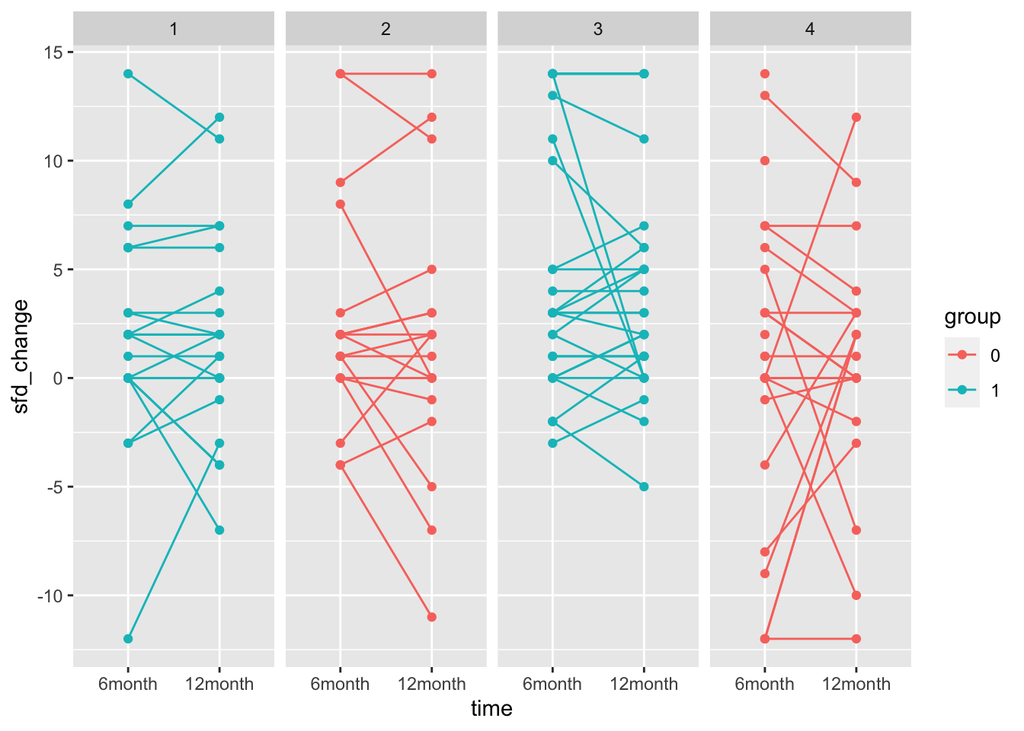

```r
df_transform <- df %>%
  select(-time_int) %>%
  pivot_wider(
    names_from = time,
    names_prefix = "obs",
    values_from = sfd
  ) %>%
  mutate(
    diff_6month = obs2 - obs1,
    diff_12month = obs3- obs1
  ) %>%
  rename(baseline = obs1) %>%
  select(-c(obs2, obs3)) %>%
  pivot_longer(
    c(diff_6month, diff_12month),
    names_to = "time",
    names_prefix = "diff_",
    values_to = "sfd_change"
  ) %>%
  mutate(
    time = factor(time, levels = c("6month", "12month"))
  )

df_transform %>%
  ggplot(aes(x=time, y=sfd_change, group = id, color= group)) +
  geom_point() +
  geom_line() +
  facet_grid(~school)
```

Now I can fit a regular mixed effect model using this change as a continuous outcome

```r
library("lmerTest")
mod1 <- lmer(sfd_change ~ baseline + group + time + group*time + (1|school)  + (1|id),
             data = df_transform)
```

```
## boundary (singular) fit: see help('isSingular')
```

```r
# mod1 <- lmer(sfd_change ~ group + time + group*time + (1|school) + (1|id),
#              data = df_transform)

summary(mod1)
```

```
## Linear mixed model fit by REML. t-tests use Satterthwaite's method [
## lmerModLmerTest]
## Formula: sfd_change ~ baseline + group + time + group * time + (1 | school) +
##     (1 | id)
##    Data: df_transform
##
## REML criterion at convergence: 1044.8
##
## Scaled residuals:
##     Min      1Q  Median      3Q     Max
## -2.9140 -0.1574  0.2706  0.4826  1.5553
##
## Random effects:
##  Groups   Name        Variance Std.Dev.
##  id       (Intercept)  4.221   2.055
##  school   (Intercept)  0.000   0.000
##  Residual             10.560   3.250
## Number of obs: 191, groups:  id, 100; school, 4
##
## Fixed effects:
##                     Estimate Std. Error        df t value Pr(>|t|)
## (Intercept)          9.29391    0.85032 129.23441  10.930   <2e-16 ***
## baseline            -0.82244    0.06613  96.75344 -12.437   <2e-16 ***
## group1               1.08100    0.77914 173.25574   1.387    0.167
## time12month         -0.04702    0.69509  96.54623  -0.068    0.946
## group1:time12month  -0.26952    0.94978  95.86247  -0.284    0.777
## ---
## Signif. codes:  0 '***' 0.001 '**' 0.01 '*' 0.05 '.' 0.1 ' ' 1
##
## Correlation of Fixed Effects:
##             (Intr) baseln group1 tm12mn
## baseline    -0.746
## group1      -0.532  0.064
## time12month -0.372 -0.025  0.425
## grp1:tm12mn  0.273  0.018 -0.587 -0.732
## optimizer (nloptwrap) convergence code: 0 (OK)
## boundary (singular) fit: see help('isSingular')
```

```r
#group = ifelse(group == 0 , "Control", "Intervention")
 df %>%
  select(-time_int) %>%
  pivot_wider(
    names_from = time,
    names_prefix = "obs",
    values_from = sfd
  ) %>%
  mutate(
    `Change_6months` = obs2 - obs1,
    `Change_12months` = obs3- obs1
  ) %>%
  rename(baseline = obs1) %>%
  select(-c(obs2, obs3)) %>%
  mutate(
    school = case_when(
      school == 1 ~ "School 1",
      school == 2 ~ "School 2",
      school == 3 ~ "School 3",
      school == 4 ~ "School 4",
    ),
    school = factor( school,
                     levels = c("School 1", "School 3", "School 2", "School 4"))
  ) %>%
  select(-c(group,id)) %>%
  tbl_summary(by=school) %>%
  add_overall() %>%
  modify_spanning_header(c("stat_1", "stat_2") ~ "**Group Control**") %>%
  modify_spanning_header(c("stat_3", "stat_4") ~ "**Group Intervention**") #%>%
```

[output not shown]

<sup>1</sup> Median (IQR)

```r
 df %>%
  select(-time_int) %>%
  pivot_wider(
    names_from = time,
    names_prefix = "obs",
    values_from = sfd
  ) %>%
  mutate(
    `Change_6months` = obs2 - obs1,
    `Change_12months` = obs3- obs1
  ) %>%
  rename(baseline = obs1) %>%
  select(-c(obs2, obs3)) %>%
  mutate(
    school = case_when(
      school == 1 ~ "School 1",
      school == 2 ~ "School 2",
      school == 3 ~ "School 3",
      school == 4 ~ "School 4",
    ),
    school = factor( school, levels = c("School 1", "School 3", "School 2", "School 4"))
  ) %>%
  select(-c(group,id, school)) %>%
  md.pattern(rotate.names = TRUE)
```

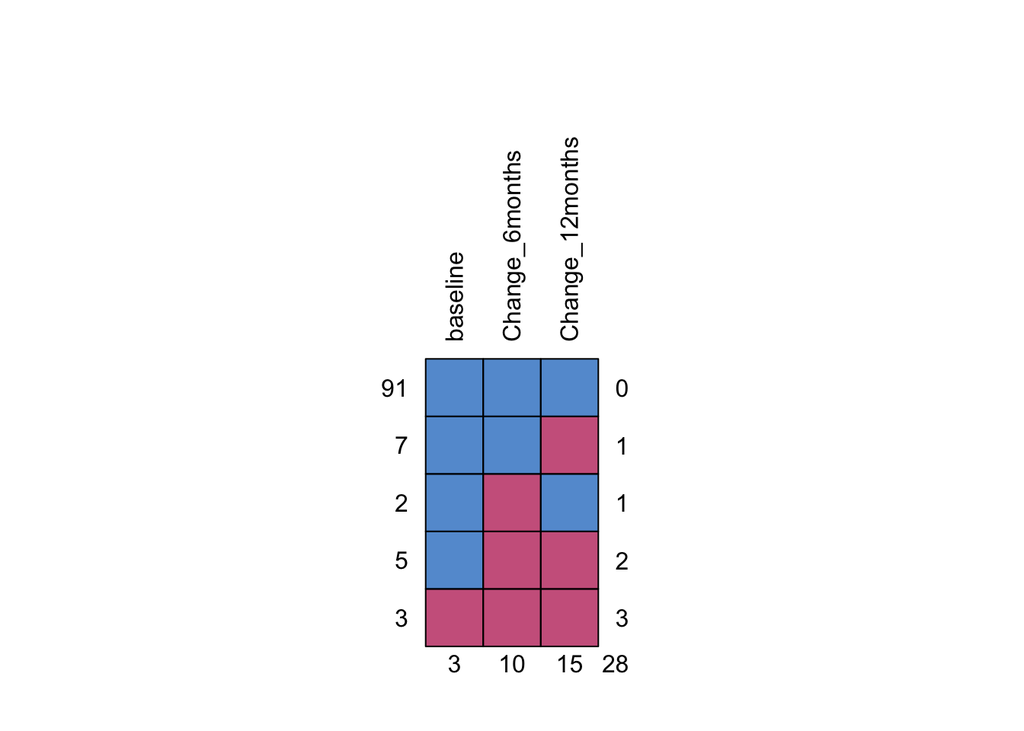

```
##    baseline Change_6months Change_12months
## 91        1              1               1  0
## 7         1              1               0  1
## 2         1              0               1  1
## 5         1              0               0  2
## 3         0              0               0  3
##           3             10              15 28
```

### Sample Size Power Stuff

[PASS all](https://www.ncss.com/software/pass/pass-documentation/)

[Resource:](https://www.ncss.com/wp-content/themes/ncss/pdf/Procedures/PASS/Mixed_Models_Tests_for_Two_Means_in_a_2-Level_Hierarchical_Design-Level-2_Randomization.pdf)

### From the textbook:

We want to compare Group Intervention vs Group Control.

Let the observations be denoted

$$Y_{ij} = 1, \dots, n \ \ (\textrm{main
unit}); \ \ j=1, \dots, m_i \ \ (\textrm{subunit})$$

By design we want to set up $m_i= m$ so that all the main units contain the same number of subunits.

A random effect model is useful to induce the correlation among the subunits as follows:

$$Y_{ij} = \mu_i + e_{ij}$$

Thus the total variance of an observation $Y_{ij}$ and the covariance between observations is $Y_{ij}$ and $Y_{ik}$ within the $i$th cluster are

$$Var(Y_{ij}) = \sigma^2 = \sigma^2_b +
\sigma^2_w$$

$$Cov(Y_{ij}, Y_{ik}) = Var (\mu_i) =
\sigma_b^2$$
Thus the correlation among subunits within a cluster equals $\rho = \frac{\sigma^2_b}{\sigma^2}$. This correlation is the same across all subunits and is called the compound symmetry model in the repeated measures context.

We model the data from group $X$ the same way, except that $E[\mu_i]=\mu_x$ for clusters of $X$.

We can now use the formula used for means for continuous outcomes

$$n= \frac{2\sigma^2
[1+(m-1)\rho](z_{\alpha / 2} + z_{\beta})^2}{m\Delta^2}$$

- $m$ we need to find this
- $\beta$ = 1- power
- $\Delta$ mean difference between the two groups and is given by the problem (1/3)
- $\rho = \frac{\sigma^2_b}{\sigma^2}$
- $\alpha$ need to do a bonforini correction for the 4 observations points
- $z_{\alpha/2}$, $z_{\beta}$ based on the normal distribution

```r
mod1 <- lmer(sfd_change ~ baseline + group + time + group*time + (1|school)  + (1|id),
             data = df_transform)
```

```
## boundary (singular) fit: see help('isSingular')
```

```r
mod1 <- lmer(sfd_change ~  group + time + group*time + (1|school)  + (1|id),
             data = df_transform)
# summary(mod1)

# given by the directions
k = 4 # number of assessments
n =  30/2 # number of schools
beta = 0.2 # 1 - power = 1 - 0.8
alpha = 0.05 / (2*k) # bonforinit adjustment
delta = 1/3
z.alpha = qnorm(1-alpha)
z.beta = qnorm(1-beta)

# given by the model
m1 = summary(mod1)
sig = m1$varcor %>% as.data.frame() %>% pull(vcov)
sigma.b = sig[2] # between-cluster variability
sigma.w = sig[1] # within cluster between sub unit variability
sigma = sigma.b + sigma.w
rho = sigma.b / sigma
rho
```

```
## [1] 0.01823346
```

```r
# putting it all together to find m
m = (2*(1-rho)*((z.alpha + z.beta)^2))/(n*(delta^2) - 2*rho*(z.alpha + z.beta)^2)
n = (2*(1+(m-1)*rho)*(z.alpha + z.beta)^2)/(m*(delta^2))
cbind(m, 15*m)
```

```
##             m
## [1,] 17.37715 260.6572
```

```r
N = (2*(z.alpha+ z.beta)^2/(delta)^2)
m = (1-rho)/(15/N-rho)
N_star = N*(1+(m-1)*rho)
cbind(N_star, m)
```

```
##        N_star        m
## [1,] 260.6572 17.37715
```